# Regresion Lineal

CARLOS ALEX NINA GUARDAPUCLLA

2022-11-28

## **IMPORTACION DE BIBLIOTECAS**

```r
library(tidyverse)
library(dplyr)
library(DataExplorer)
library(mice)
library(GGally)
library(scales)
library(psych)
```

```r
library(corrplot)
```

Leer dataset

```r
df <- read.csv("datos/precios_venta_alquiler_depa.csv", stringsAsFactors = TRUE)
head(df)
```

```
##    Tipo Precio.en.soles.corrientes Superficie Número.de.habitaciones
## 1 venta                     384737        200                      4
## 2 venta                     227992        120                      4
## 3 venta                     327739        145                      3
## 4 venta                     159595         80                      3
## 5 venta                     210893         88                      2
## 6 venta                     313489         98                      3
##   Número.de.baños Número.de.garajes Piso.de.ubicación Vista.al.exterior
## 1               4                 2                 2                 1
## 2               3                 1                 2                 1
## 3               4                 1                 3                 0
## 4               2                 1                 3                 1
## 5               2                 1                 4                 0
## 6               3                 1                 6                 1
##   Años.de.antigüedad
## 1                 10
## 2                  9
## 3                 10
## 4                  0
## 5                 22
## 6                  0
```

mostrar dimensiones del dataset

```r
dim(df)
```

```
## [1] 79614     9
```

verificar tipos de datos contenidos en el dataset

```r
str(df)
```

```
## 'data.frame':    79614 obs. of  9 variables:
##  $ Tipo                      : Factor w/ 2 levels "alquiler","venta": 2 2 2 2 2 2 2 2 2 2 ...
##  $ Precio.en.soles.corrientes: num  384737 227992 327739 159595 210893 ...
##  $ Superficie                : int  200 120 145 80 88 98 97 119 130 153 ...
##  $ Número.de.habitaciones    : num  4 4 3 3 2 3 2 3 3 3 ...
##  $ Número.de.baños           : num  4 3 4 2 2 3 2 4 3 3 ...
##  $ Número.de.garajes         : int  2 1 1 1 1 1 1 2 2 1 ...
##  $ Piso.de.ubicación         : int  2 2 3 3 4 6 5 3 16 4 ...
##  $ Vista.al.exterior         : int  1 1 0 1 0 1 0 1 1 1 ...
##  $ Años.de.antigüedad        : int  10 9 10 0 22 0 0 6 2 20 ...
```

resumen estadístico

```r
summary(df)
```

```
##        Tipo       Precio.en.soles.corrientes   Superficie
##  alquiler:37341   Min.   :     167           Min.   : 15.0
##  venta   :42273   1st Qu.:    2591           1st Qu.: 80.0
##                   Median :  173669           Median :100.0
##                   Mean   :  292387           Mean   :111.7
##                   3rd Qu.:  447317           3rd Qu.:128.0
##                   Max.   :11372361           Max.   :950.0
##  Número.de.habitaciones Número.de.baños Número.de.garajes Piso.de.ubicación
##  Min.   : 0.00          Min.   :0.000   Min.   : 0.0000   Min.   : 1.000
##  1st Qu.: 2.00          1st Qu.:2.000   1st Qu.: 0.0000   1st Qu.: 2.000
##  Median : 3.00          Median :2.000   Median : 1.0000   Median : 3.000
##  Mean   : 2.64          Mean   :2.277   Mean   : 0.8881   Mean   : 4.299
##  3rd Qu.: 3.00          3rd Qu.:3.000   3rd Qu.: 1.0000   3rd Qu.: 6.000
##  Max.   :32.00          Max.   :8.000   Max.   :31.0000   Max.   :30.000
##  Vista.al.exterior Años.de.antigüedad
##  Min.   : 0.0000   Min.   : 0.000
##  1st Qu.: 1.0000   1st Qu.: 2.000
##  Median : 1.0000   Median : 5.000
##  Mean   : 0.8993   Mean   : 8.467
##  3rd Qu.: 1.0000   3rd Qu.:10.000
##  Max.   :11.0000   Max.   :95.000
```

Visualización de datos

- diagrama de dispersión

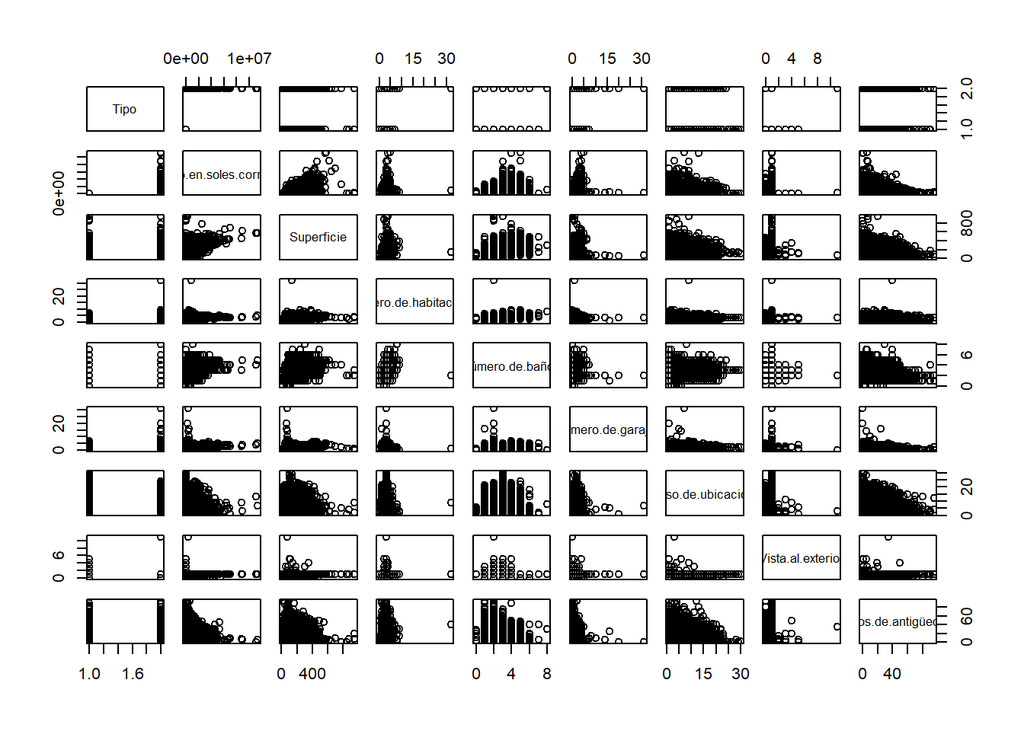

```r
plot(df)
```

- histograma

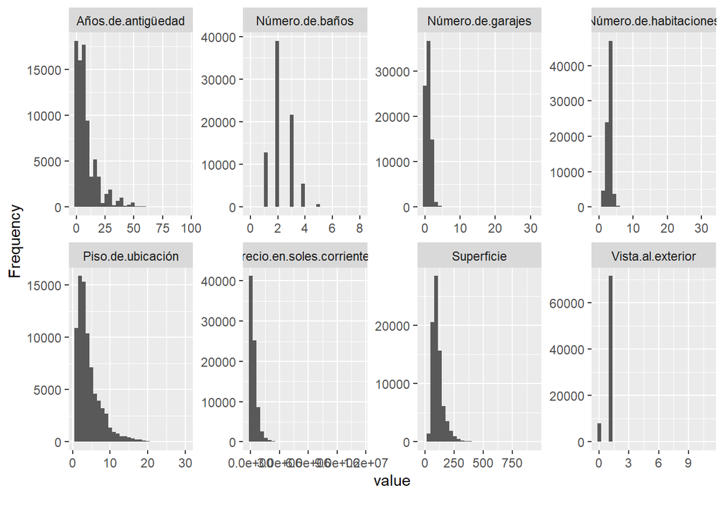

```r
plot_histogram(df)
```

Eliminar filas y/o columnas poco relevantes

- Conservar los datos de ventas

```r
df_venta <- df[!(df$Tipo == 'alquiler'),]
df_venta <- df_venta[,-c(1,1)]
head(df_venta)
```

```
##   Precio.en.soles.corrientes Superficie Número.de.habitaciones Número.de.baños
## 1                     384737        200                      4               4
## 2                     227992        120                      4               3
## 3                     327739        145                      3               4
## 4                     159595         80                      3               2
## 5                     210893         88                      2               2
## 6                     313489         98                      3               3
##   Número.de.garajes Piso.de.ubicación Vista.al.exterior Años.de.antigüedad
## 1                 2                 2                 1                 10
## 2                 1                 2                 1                  9
## 3                 1                 3                 0                 10
## 4                 1                 3                 1                  0
## 5                 1                 4                 0                 22
## 6                 1                 6                 1                  0
```

verificar tipos de datos contenidos en el nuevo dataset

```r
str(df_venta)
```

```
## 'data.frame':    42273 obs. of  8 variables:
##  $ Precio.en.soles.corrientes: num  384737 227992 327739 159595 210893 ...
##  $ Superficie                : int  200 120 145 80 88 98 97 119 130 153 ...
##  $ Número.de.habitaciones    : num  4 4 3 3 2 3 2 3 3 3 ...
##  $ Número.de.baños           : num  4 3 4 2 2 3 2 4 3 3 ...
##  $ Número.de.garajes         : int  2 1 1 1 1 1 1 2 2 1 ...
##  $ Piso.de.ubicación         : int  2 2 3 3 4 6 5 3 16 4 ...
##  $ Vista.al.exterior         : int  1 1 0 1 0 1 0 1 1 1 ...
##  $ Años.de.antigüedad        : int  10 9 10 0 22 0 0 6 2 20 ...
```

mostrar dimensiones del nuevo dataset

```r
dim(df_venta)
```

```
## [1] 42273     8
```

resumen estadístico de ventas

```r
summary(df_venta)
```

```
##  Precio.en.soles.corrientes   Superficie    Número.de.habitaciones
##  Min.   :   22054           Min.   : 15.0   Min.   : 0.000
##  1st Qu.:  283480           1st Qu.: 79.0   1st Qu.: 2.000
##  Median :  426500           Median : 99.0   Median : 3.000
##  Mean   :  548178           Mean   :112.6   Mean   : 2.741
##  3rd Qu.:  664512           3rd Qu.:130.0   3rd Qu.: 3.000
##  Max.   :11372361           Max.   :950.0   Max.   :32.000
##  Número.de.baños Número.de.garajes Piso.de.ubicación Vista.al.exterior
##  Min.   :0.000   Min.   : 0.0000   Min.   : 1.000    Min.   : 0.0000
##  1st Qu.:2.000   1st Qu.: 0.0000   1st Qu.: 2.000    1st Qu.: 1.0000
##  Median :2.000   Median : 1.0000   Median : 3.000    Median : 1.0000
##  Mean   :2.296   Mean   : 0.8343   Mean   : 4.198    Mean   : 0.8853
##  3rd Qu.:3.000   3rd Qu.: 1.0000   3rd Qu.: 5.000    3rd Qu.: 1.0000
##  Max.   :8.000   Max.   :31.0000   Max.   :24.000    Max.   :11.0000
##  Años.de.antigüedad
##  Min.   : 0.000
##  1st Qu.: 1.000
##  Median : 5.000
##  Mean   : 9.319
##  3rd Qu.:12.000
##  Max.   :95.000
```

verificar si existen datos nulos

```r
sum(is.na(df_venta))
```

```
## [1] 0
```

```
##  /\     /\
## {  `---'  }
## {  O   O  }
## ==>  V <==  No need for mice. This data set is completely observed.
##  \  \|/  /
##   `-----'
```

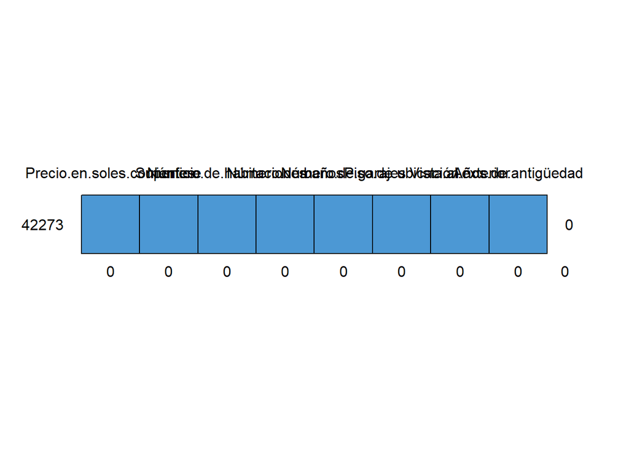

```
##       Precio.en.soles.corrientes Superficie Número.de.habitaciones
## 42273                          1          1                      1
##                                0          0                      0
##       Número.de.baños Número.de.garajes Piso.de.ubicación Vista.al.exterior
## 42273               1                 1                 1                 1
##                     0                 0                 0                 0
##       Años.de.antigüedad
## 42273                  1 0
##                        0 0
```

```r
md.pattern(df_venta)
```

Busqueda de outliers - diagrama de boxplot

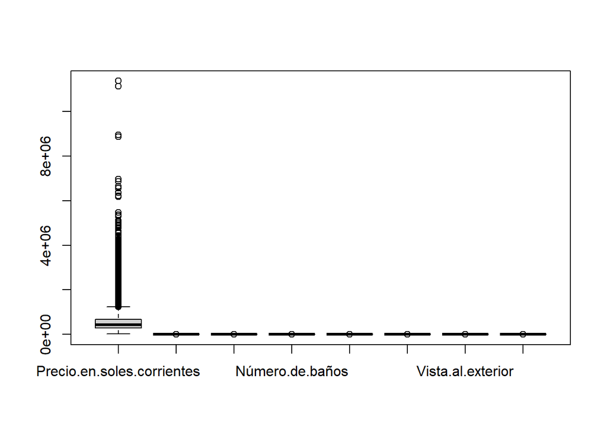

```r
boxplot(df_venta)
```

Tratamiento de outliers

```r
tratamiento_outliers <- function(df,colum){

  qrts <- quantile(df[colum], probs = c(0.25, 0.75), na.rm = TRUE)
  caps <- quantile(df[colum], probs = c(.05, .95), na.rm = TRUE)
  iqr <- qrts[2]-qrts[1]
  h <- 1.5 * iqr
  df[colum][df[colum]<qrts[1]-h] <- caps[1]
  df[colum][df[colum]>qrts[2]+h] <- caps[2]

  return(df)
}
```

crear una copia de los datos

```r
df_sin_outlier <- df_venta
```

aplicar la funcion sobre todas las columnas

```r
for (name in seq_along(df_sin_outlier)){
  df_sin_outlier <- tratamiento_outliers(df_sin_outlier, name)
}
```

dimensiones del dataset despues del tratamiento de outliers

```r
dim(df_sin_outlier)
```

```
## [1] 42273     8
```

dataset despues del tratamiento de outliers

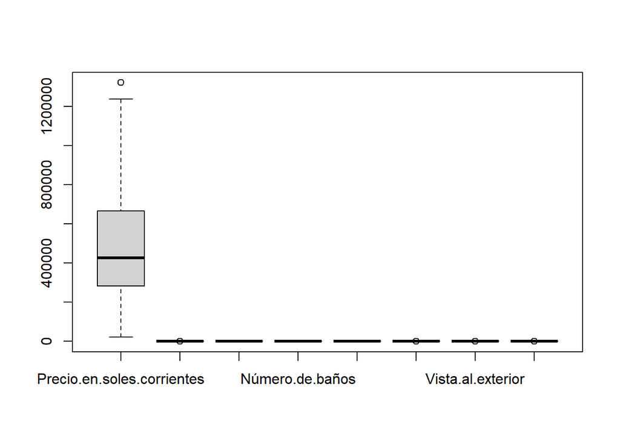

```r
boxplot(df_sin_outlier)
```

resumen estadístico

```r
summary(df_sin_outlier)
```

```
##  Precio.en.soles.corrientes   Superficie    Número.de.habitaciones
##  Min.   :  22054            Min.   : 15.0   Min.   :1.000
##  1st Qu.: 283480            1st Qu.: 79.0   1st Qu.:2.000
##  Median : 426500            Median : 99.0   Median :3.000
##  Mean   : 517811            Mean   :109.8   Mean   :2.733
##  3rd Qu.: 664512            3rd Qu.:130.0   3rd Qu.:3.000
##  Max.   :1320430            Max.   :218.0   Max.   :4.000
##  Número.de.baños Número.de.garajes Piso.de.ubicación Vista.al.exterior
##  Min.   :1.000   Min.   :0.0000    Min.   : 1.000    Min.   :0.0000
##  1st Qu.:2.000   1st Qu.:0.0000    1st Qu.: 2.000    1st Qu.:1.0000
##  Median :2.000   Median :1.0000    Median : 3.000    Median :1.0000
##  Mean   :2.285   Mean   :0.8068    Mean   : 4.028    Mean   :0.8851
##  3rd Qu.:3.000   3rd Qu.:1.0000    3rd Qu.: 5.000    3rd Qu.:1.0000
##  Max.   :4.000   Max.   :2.0000    Max.   :10.000    Max.   :1.0000
##  Años.de.antigüedad
##  Min.   : 0.000
##  1st Qu.: 1.000
##  Median : 5.000
##  Mean   : 9.057
##  3rd Qu.:12.000
##  Max.   :35.000
```

## **PREPROCESAMIENTO DE DATOS**

reescalando los valores

```r
scaled_data <- scale(df_sin_outlier)
df_scaled=as.data.frame(scaled_data)
head(df_scaled)
```

```
##   Precio.en.soles.corrientes Superficie Número.de.habitaciones Número.de.baños
## 1                 -0.4226627  2.0863269              1.9880754       2.1267777
## 2                 -0.9205094  0.2349008              1.9880754       0.8866537
## 3                 -0.6036973  0.8134714              0.4193684       2.1267777
## 4                 -1.1377489 -0.6908122              0.4193684      -0.3534704
## 5                 -0.9748185 -0.5056696             -1.1493387      -0.3534704
## 6                 -0.6489575 -0.2742414              0.4193684       0.8866537
##   Número.de.garajes Piso.de.ubicación Vista.al.exterior Años.de.antigüedad
## 1         1.6202008       -0.77866901         0.3602884        0.093109069
## 2         0.2623889       -0.77866901         0.3602884       -0.005636532
## 3         0.2623889       -0.39471153        -2.7754889        0.093109069
## 4         0.2623889       -0.39471153         0.3602884       -0.894346944
## 5         0.2623889       -0.01075404        -2.7754889        1.278056284
## 6         0.2623889        0.75716093         0.3602884       -0.894346944
```

correlacion lineal

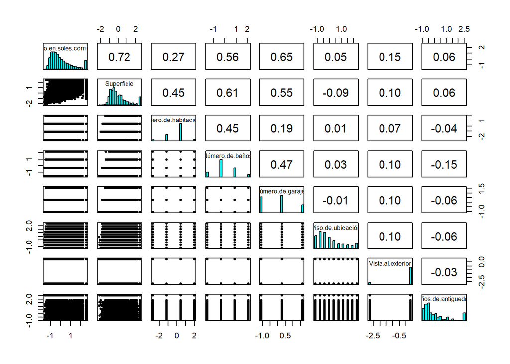

```r
pairs.panels(df_scaled,
             method = "spearman",
             density=FALSE,
             ellipses=FALSE,
             smooth = FALSE)
```

matriz de correlación

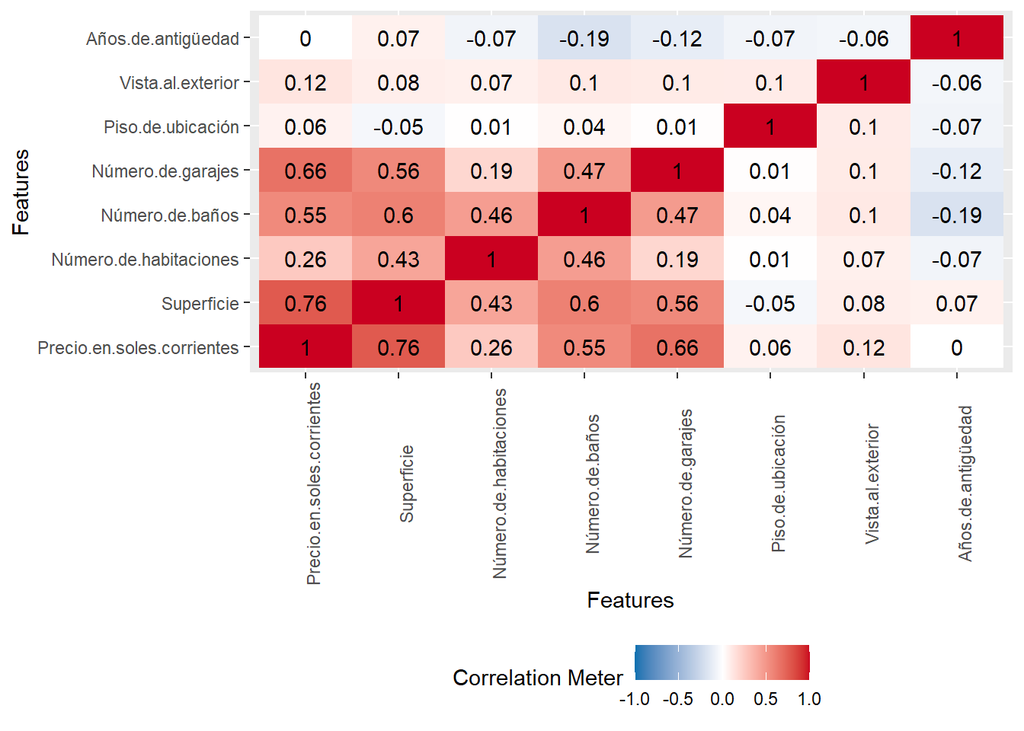

```r
plot_correlation(df_scaled)
```

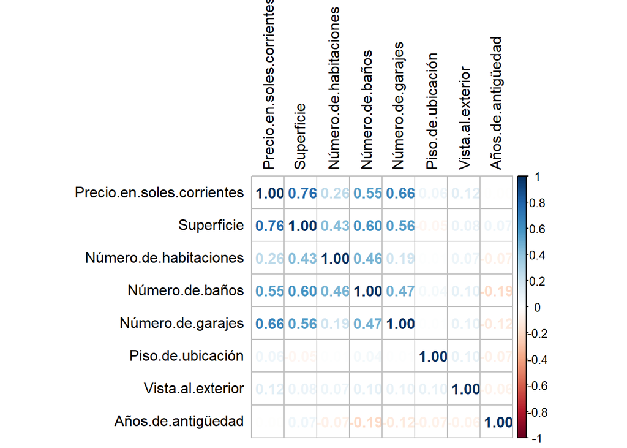

```r
corrplot(cor(df_scaled),        # Matriz de correlación
         method = "number", # Método para el gráfico de correlación
         type = "full",    # Estilo del gráfico (también "upper" y "lower")
         diag = TRUE,      # Si TRUE (por defecto), añade la diagonal
         tl.col = "black", # Color de las etiquetas
         bg = "white",     # Color de fondo
         title = "",       # Título
         col = NULL)       # Paleta de colores
```

# Extraer solo las columnas necesaria

```r
df_scaled2 <- df_scaled[,c(1,2)]
head(df_scaled2)
```

```
##   Precio.en.soles.corrientes Superficie
## 1                 -0.4226627  2.0863269
## 2                 -0.9205094  0.2349008
## 3                 -0.6036973  0.8134714
## 4                 -1.1377489 -0.6908122
## 5                 -0.9748185 -0.5056696
## 6                 -0.6489575 -0.2742414
```

Dividir los datos

```r
#install.packages("caret", dependencies = c("Depends", "Suggests"))
```

```r
library(ggplot2)
library(lattice)
library(caret)
set.seed(123)
# Se crean los índices de las observaciones de entrenamiento
train <- createDataPartition(y = df_scaled2$Precio.en.soles.corrientes, p = 0.8, list = FALSE, times = 1)
datos_train <- df_scaled2[train, ]
datos_test  <- df_scaled2[-train, ]
```

```r
dim(datos_train)
```

```
## [1] 33820     2
```

verificar la distribucion de la variable respuesta

```r
dim(prop.table(table(datos_train$Precio.en.soles.corrientes)))
```

```
## [1] 11761
```

```r
dim(prop.table(table(datos_test$Precio.en.soles.corrientes)))
```

```
## [1] 4870
```

Regresion lineal simple

- Cálculo y representacion de la recta de mínimos cuadrados
  - precio y superficie

```r
# lm(variable dependiente y ~ variable independiente x, dataset)
modelo_regresion <- lm(Precio.en.soles.corrientes ~ Superficie, data = datos_train, na.action = na.exclude)
summary(modelo_regresion)
```

```
##
## Call:
## lm(formula = Precio.en.soles.corrientes ~ Superficie, data = datos_train,
##     na.action = na.exclude)
##
## Residuals:
##     Min      1Q  Median      3Q     Max
## -3.3519 -0.3975 -0.0238  0.3955  3.4308
##
## Coefficients:
##               Estimate Std. Error t value Pr(>|t|)
## (Intercept) -0.0002422  0.0035011  -0.069    0.945
## Superficie   0.7638820  0.0034963 218.481   <2e-16 ***
## ---
## Signif. codes:  0 '***' 0.001 '**' 0.01 '*' 0.05 '.' 0.1 ' ' 1
##
## Residual standard error: 0.6439 on 33818 degrees of freedom
## Multiple R-squared:  0.5853, Adjusted R-squared:  0.5853
## F-statistic: 4.773e+04 on 1 and 33818 DF,  p-value: < 2.2e-16
```

```r
modelo_regresion$coefficients
```

```
##   (Intercept)    Superficie
## -0.0002421535  0.7638820405
```

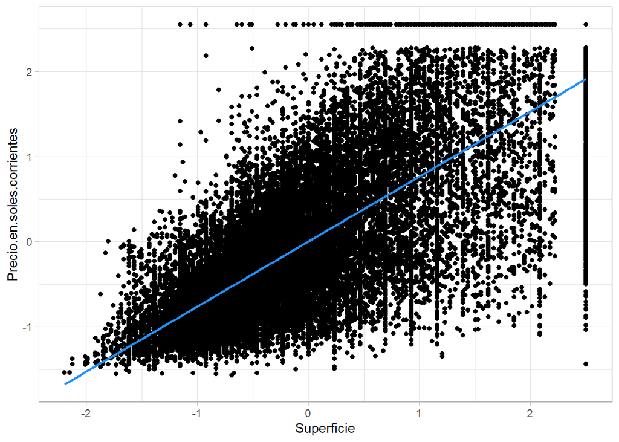

```r
ggplot(datos_train, aes(x=Superficie, y=Precio.en.soles.corrientes)) +
  geom_point() +
  geom_smooth(method='lm', formula=y~x, se=FALSE, col='dodgerblue1') +
  theme_light()
```

crear un vector de predicciones basado en el propio conjunto de entrenamiento

```r
y_predict <- predict(modelo_regresion, datos_train)
```

construimos la gráfica

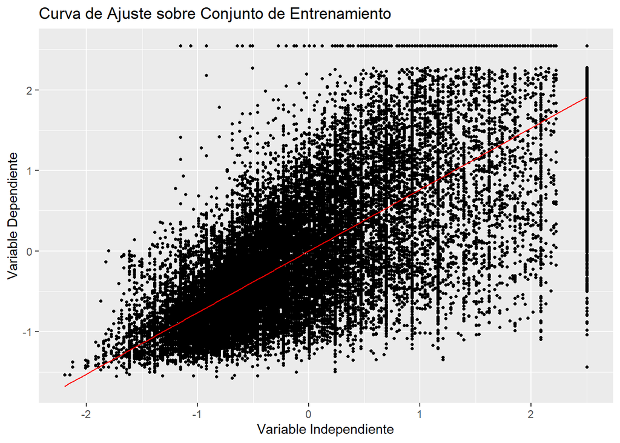

```r
ggplot() + geom_point(data = datos_train, aes(x = Superficie, y = Precio.en.soles.corrientes), size = 0.9) +
  geom_line(aes( x = datos_train$Superficie, y = y_predict), color = "red") +
  xlab("Variable Independiente") +
  ylab("Variable Dependiente") +
  ggtitle("Curva de Ajuste sobre Conjunto de Entrenamiento")
```

realizar predicciones sobre el conjunto de validación

```r
y_test_predict <- predict(modelo_regresion, datos_test)
```

construimos la gráfica

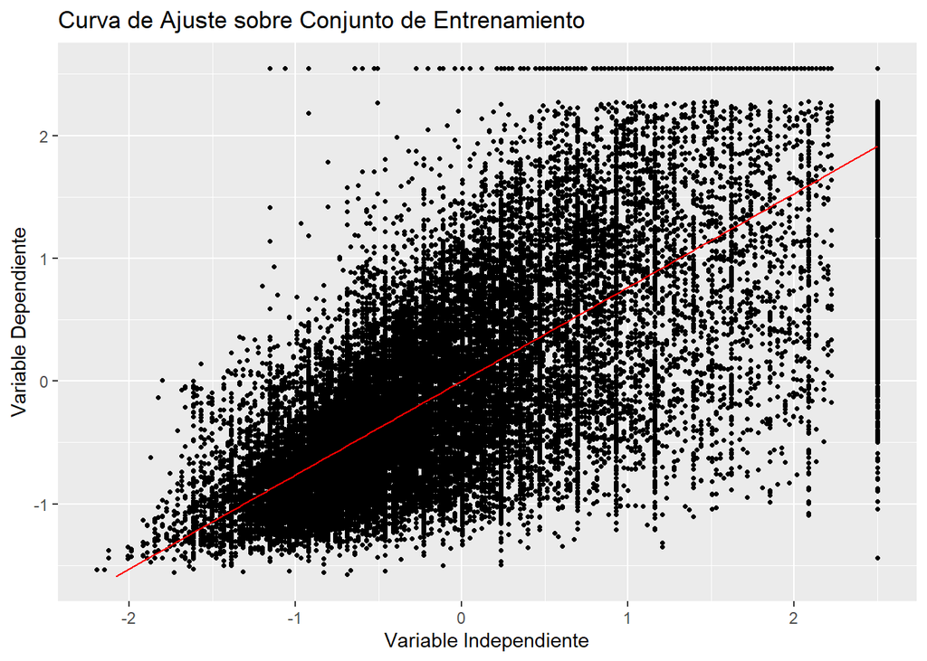

```r
ggplot() + geom_point(data = datos_train, aes(x = Superficie, y = Precio.en.soles.corrientes), size = 0.9) +
  geom_line(aes( x = datos_test$Superficie, y = y_test_predict), color = "red") +
  xlab("Variable Independiente") +
  ylab("Variable Dependiente") +
  ggtitle("Curva de Ajuste sobre Conjunto de Entrenamiento")
```

veamos la correlación existente entre los valores y del conjunto de prueba, y los valores predichos para dicho conjunto

```r
cor(datos_train$Precio.en.soles.corrientes, y_predict)
```

```
## [1] 0.7650613
```

```r
cor(datos_test$Precio.en.soles.corrientes, y_test_predict)
```

```
## [1] 0.7628412
```

el valor 0.7628412 indica una fuerte correlación y, por lo tanto, un buen ajuste a los datos por parte del modelo obtenido.

```r
objeto <- Precio.en.soles.corrientes ~ Superficie
```

bootstrap

```r
# define trining control
set.seed(123)
metodo_boot <- trainControl(method = "boot", number = 100)

# fit a regresion model
model_boot <- train(objeto,
                    data = datos_test,
                    method = "lm",
                    trControl = metodo_boot)

print(model_boot)
```

```
## Linear Regression
##
## 8453 samples
##    1 predictor
##
## No pre-processing
## Resampling: Bootstrapped (100 reps)
## Summary of sample sizes: 8453, 8453, 8453, 8453, 8453, 8453, ...
## Resampling results:
##
##   RMSE      Rsquared   MAE
##   0.646408  0.5822072  0.4955757
##
## Tuning parameter 'intercept' was held constant at a value of TRUE
```

metodo de validacion cruzada

```r
# define trining control
set.seed(123)
metodo_cv <- trainControl(method = "cv", number = 100)

# fit a regresion model
model_cv <- train(objeto,
                    data = datos_test,
                    method = "lm",
                    trControl = metodo_cv)

print(model_cv)
```

```
## Linear Regression
##
## 8453 samples
##    1 predictor
##
## No pre-processing
## Resampling: Cross-Validated (100 fold)
## Summary of sample sizes: 8368, 8369, 8368, 8369, 8369, 8369, ...
## Resampling results:
##
##   RMSE       Rsquared   MAE
##   0.6448286  0.5857115  0.4959265
##
## Tuning parameter 'intercept' was held constant at a value of TRUE
```

metodo LOOCV

```r
# define trining control
set.seed(123)
metodo_LOOVC <- trainControl(method = "LOOCV")

# fit a regresion model
model_LOOVC <- train(objeto,
                    data = datos_test,
                    method = "lm",
                    trControl = metodo_LOOVC)

print(model_LOOVC)
```

```
## Linear Regression
##
## 8453 samples
##    1 predictor
##
## No pre-processing
## Resampling: Leave-One-Out Cross-Validation
## Summary of sample sizes: 8452, 8452, 8452, 8452, 8452, 8452, ...
## Resampling results:
##
##   RMSE       Rsquared   MAE
##   0.6472439  0.5816715  0.4959273
##
## Tuning parameter 'intercept' was held constant at a value of TRUE
```

METODO DE VALIDACION REPETIDA

```r
# define trining control
set.seed(123)
metodo_repeatedcv <- trainControl(method = "repeatedcv", repeats = 10)

# fit a regresion model
model_repeatedcv <- train(objeto,
                    data = datos_test,
                    method = "lm",
                    trControl = metodo_repeatedcv)

print(model_repeatedcv)
```

```
## Linear Regression
##
## 8453 samples
##    1 predictor
##
## No pre-processing
## Resampling: Cross-Validated (10 fold, repeated 10 times)
## Summary of sample sizes: 7608, 7606, 7609, 7607, 7609, 7606, ...
## Resampling results:
##
##   RMSE       Rsquared   MAE
##   0.6469426  0.5822887  0.4958811
##
## Tuning parameter 'intercept' was held constant at a value of TRUE
```